# Project 4

Sod Shock Tube problem is test case commonly used in computational hydrodynamics (CFD, SPH, etc) to see how well a certain computational approach works.

It also helps in revealing the flaws in an approach (numerical scheme, etc).

The implementation uses the initial conditions as proposed by G.A. Sod in ”A Survey of Several Finite Difference Methods for Systems of Nonlinear Hyperbolic Conservation Laws”, JCP (1978).

In this project, you are asked

1. **To find the exact solution of the Sod problem**

   There are matlab code available on the mathwork. You can download the code and test it and write a summary about it.
2. **To test the following schemes for the Sod problem**
   1. Godunov scheme
   2. Lax-Friedrichs scheme
   3. Lax-Wendroff scheme
   4. WENO4, RK2
   5. WENO3, RK2

## Exact Solution

The code of the exact solution refers to [here](https://www.mathworks.com/matlabcentral/fileexchange/46311-sod-shock-tube-problem-solver)

And the simulation result is like this

[figure not shown]

### Summary

We can find that there are discontinuity occurs in the diagrams, and there are three jumps in the density curve, which are rarefraction wave, contact layer and shock wave, respectively.

And in the velocity diagram, it's just like wave in inviscid Burger's eqaution, which will compress right continuously.

And note that, the pressure before and after the contact discontinuity remain the same.

## Import Necessary Libraries

```python
import matplotlib.pyplot as plt
from matplotlib import animation
from IPython.display import HTML
import numpy as np
np.seterr(all="ignore")
%matplotlib inline
plt.rcParams['figure.figsize'] = [16, 4]
```

## Domain and Initial Condition

density: $$\rho_l = 1, \rho_r = 0.125$$

velocity: $$v_l = 0, v_l = 0$$

pressure: $$p_l = 1,p_r = 0.1$$

```python
global dx
global dt
dx = 1e-3
cfl = 0.1
dt = cfl * dx
T = 0.1
time = np.arange(0, T, dt, dtype='float64')
L = 0.2
space = np.arange(-L, L, dx, dtype='float64')

# constants
global gamma
gamma = 1.4

# >>> initial condtions
# density
rho0 = np.zeros(space.shape)
rho0[space < 0] = 1.0
rho0[space >= 0] = 0.125

# velocity
v0 = np.zeros(space.shape)

# pressure
p0 = np.zeros(space.shape)
p0[space < 0] = 1.0
p0[space >= 0] = 0.1

# collect as state
state_names = ['density', 'velocity', 'pressure']
state0 = np.vstack((rho0, v0, p0))
```

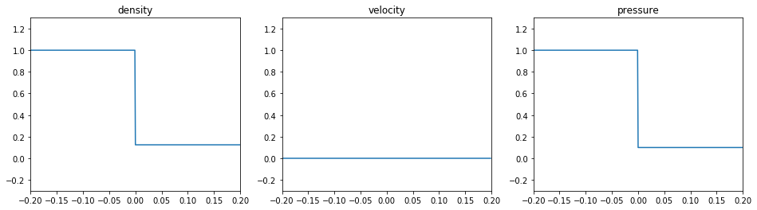

```python
fig, axes = plt.subplots(1, len(state0))
for i, ax in enumerate(axes):
    ax.plot(space, state0[i])
    ax.set_title(state_names[i])
    ax.set_xlim(-L, L)
    ax.set_ylim(-0.3, 1.3)
```

## Conservative Finite Difference Schemes

We can write the schemes for solving the conservation law equation

$$u_t + f(u)_x = 0$$

in the explicit form

$$u^{n+1}_j=u^{n}_j-\frac{\Delta t}{\Delta x}(h^{n}_{j+1/2}-h^{n}_{j-1/2})$$

where $h$ is a consistent numerical flux function of $u^{n}_j$, $u^{n}_{j+1}$, ...

$ u^{n}_j=u(j\Delta x, n\Delta t) $, $\Delta x, \Delta t$ are the partition of space and time respectively.

> For the convenience, $u_j$ represnts $u$ in a certain time, so the iterative formula becomes $$u_{j+1}=u_j-\frac{\Delta t}{\Delta x}(h_{j+1/2}-h_{j-1/2})$$

```python
def update(u, h):
    return u - dt/dx*(h - np.roll(h, 1, axis=1))
```

## Gas Dynamics

$$u = \begin{pmatrix} \rho \\ m \\ e \end{pmatrix},\ f(u)= \begin{pmatrix} m \\ \frac{m^2}{\rho}+p \\ \frac{m(e+p)}{\rho} \end{pmatrix} $$

$$ p = (\gamma-1)(e-\frac{m^2}{2\rho}),\ \gamma = 1.4 $$

$$ v = \frac{m}{\rho}$$

where $\rho$ is the density, $m$ is the momentum, $e$ is the total energy, $p$ is the pressure, $\gamma$ is the ratio of heat capacity. and $v$ is the velocity.

### * Conversion between u and state

```python
gamma = 1.4

def u2state(u):
    rho = u[0]
    m = u[1]
    state = np.copy(u)
    state[1] = m / rho
    state[2] = get_p(u)
    return state


def state2u(state):
    rho = state[0]
    v = state[1]
    p = state[2]
    u = np.copy(state)
    m = v / rho
    e = p / (gamma-1) + (rho*v**2)/2
    u[1] = m
    u[2] = e
    return u

def get_p(u):
    rho = u[0]
    m = u[1]
    e = u[2]
    return (gamma-1)*(e-m**2/(2*rho))
```

### * Initial condition of u

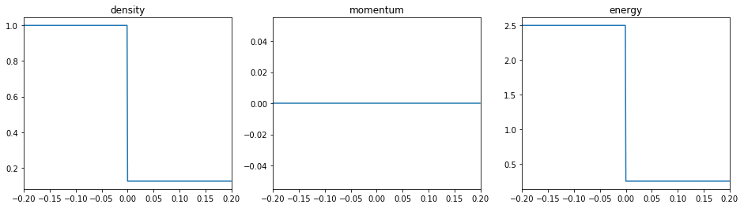

```python
u0 = state2u(state0)
u_names = ['density', 'momentum', 'energy']

fig, axes = plt.subplots(1, len(u0))
for i, ax in enumerate(axes):
    ax.plot(space, u0[i])
    ax.set_title(u_names[i])
    ax.set_xlim(-L, L)
    # ax.set_ylim(-0.3, 2.5)
```

### * Define flux

```python
def flux(u):
    rho = u[0]
    m = u[1]
    e = u[2]

    p = get_p(u)
    f = np.copy(u)
    f[0] = m
    f[1] = m**2/rho + p
    f[2] = m*(e+p)/rho
    return f
```

Initial flux

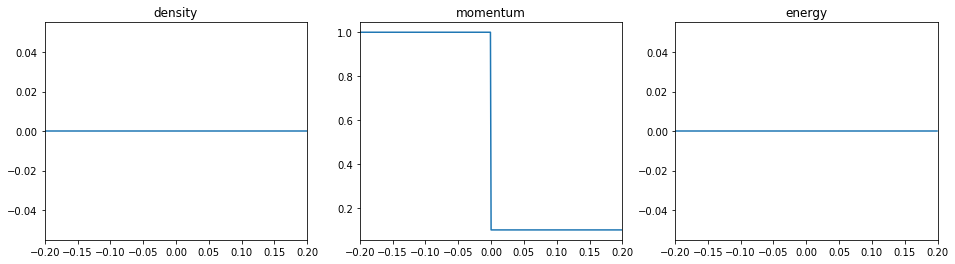

```python
u0 = state2u(state0)
f0 = flux(u0)
u_name = ['density', 'momentum', 'energy']
fig, axes = plt.subplots(1, len(u0))
for i, ax in enumerate(axes):
    ax.plot(space, f0[i])
    ax.set_title(u_name[i])
    ax.set_xlim(-L, L)
    # ax.set_ylim(-0.3, 2.5)
```

## Scheme: Godunov

The numerical flux is given by

$$h_{j+1/2}=f(\frac{u_{j+1}+u_{j}}{2}-\frac{\Delta t}{\Delta x}(f_{j+1}-f_{j}))$$

$$h_{j-1/2}=f(\frac{u_{j}+u_{j-1}}{2}-\frac{\Delta t}{\Delta x}(f_{j}-f_{j-1}))$$

```python
def Godunov(u):
    f = flux(u)
    mean_u = (np.roll(u, -1, axis=1)+u)/2
    delta_f = np.roll(f, -1, axis=1)-f
    num_flux = flux(mean_u - dt/dx*delta_f)
    return update(u, num_flux)
```

## Scheme: Lax-Wendroff

The numerical flux is given by

$$h_{j+1/2}=f(\frac{u_{j+1}+u_{j}}{2}-\frac{\Delta t}{2 \Delta x}(f_{j+1}-f_{j}))$$

$$h_{j-1/2}=f(\frac{u_{j}+u_{j-1}}{2}-\frac{\Delta t}{2 \Delta x}(f_{j}-f_{j-1}))$$

```python
def Lax_Wendroff(u):
    f = flux(u)
    mean_u = (np.roll(u, -1, axis=1)+u)/2
    delta_f = np.roll(f, -1, axis=1)-f
    num_flux = flux(mean_u - dt/dx*delta_f/2)
    return update(u, num_flux)
```

## Scheme: Lax-Friedrichs

The numerical flux is given by

$$h_{j+1/2}=\frac{1}{2}(f_{j+1}+f_{j})-\frac{\Delta x}{2 \Delta t}(u_{j+1}-u_{j})$$

$$h_{j-1/2}=\frac{1}{2}(f_{j}+f_{j-1})-\frac{\Delta x}{2 \Delta t}(u_{j}-u_{j-1})$$

```python
def Lax_Friedrichs(u):
    f = flux(u)
    mean_f = (np.roll(f, -1, axis=1)+f)/2
    delta_u = np.roll(u, -1, axis=1)-u
    num_flux = mean_f - dx/dt * delta_u/2
    return update(u, num_flux)
```

## Scheme: Runge-Kutta & WENO

### Compute max flux speed, df

$$ \max(|v|+\sqrt{\frac{\gamma \rho}{p}}) $$

```python
def max_df(u):
    state = u2state(u)
    rho = state[0]
    v = state[1]
    p = state[2]
    sound_speed = np.sqrt(gamma*rho/p)
    return np.max(abs(v) + sound_speed)
```

### WENO3

```python
def WENO3(u):

    epsilon = 1e-6
    sigma = max_df(u)

    # Lax-Friedrcihs flux splitting
    v = (flux(u)+sigma*u)/2
    w = np.roll((flux(u)-sigma*u)/2, -1, axis=1)

    # === Right Flux, v ===
    # chose positive fluxes
    vmm = np.roll(v,  2, axis=1)
    vm  = np.roll(v,  1, axis=1)
    vp  = np.roll(v, -1, axis=1)
    vpp = np.roll(v, -2, axis=1)

    # Polynomials
    p0n = (2*vmm - 7*vm + 11*v)/6
    p1n = (-vm + 5*v + 2*vp)/6
    p2n = (2*v + 5*vp - vpp)/6

    # Smooth Indicators (Beta factors)
    B0n = 13/12*(vmm-2*vm+v)**2 + 1/4*(vmm-4*vm+3*v)**2
    B1n = 13/12*(vm-2*v+vp)**2 + 1/4*(vm-vp)**2
    B2n = 13/12*(v-2*vp+vpp)**2 + 1/4*(3*v-4*vp+vpp)**2

    # Constants
    d0n = 1/10
    d1n = 6/10
    d2n = 3/10

    # Alpha weights
    alpha0n = d0n/(epsilon + B0n)**2
    alpha1n = d1n/(epsilon + B1n)**2
    alpha2n = d2n/(epsilon + B2n)**2
    alphasumn = alpha0n + alpha1n + alpha2n

    # ENO stencils weigths
    w0n = alpha0n/alphasumn
    w1n = alpha1n/alphasumn
    w2n = alpha2n/alphasumn

    # Numerical Flux at cell boundary
    hn = w0n*p0n + w1n*p1n + w2n*p2n

    # === Left Flux, w ===
    # chose negative fluxes
    wmm = np.roll(w,  2, axis=1)
    wm  = np.roll(w,  1, axis=1)
    wp  = np.roll(w, -1, axis=1)
    wpp = np.roll(w, -2, axis=1)

    # Polynomials
    p0p = (-wmm + 5*wm + 2*w)/6
    p1p = (2*wm + 5*w - wp)/6
    p2p = (11*w - 7*wp + 2*wpp)/6

    # Smooth Indicators (Beta factors)
    B0p = 13/12*(wmm-2*wm+w)**2 + 1/4*(wmm-4*wm+3*w)**2
    B1p = 13/12*(wm-2*w+wp)**2 + 1/4*(wm-wp)**2
    B2p = 13/12*(w-2*wp+wpp)**2 + 1/4*(3*w-4*wp+wpp)**2

    # Constants
    d0p = 3/10
    d1p = 6/10
    d2p = 1/10

    # Alpha weights
    alpha0p = d0p/(epsilon + B0p)**2
    alpha1p = d1p/(epsilon + B1p)**2
    alpha2p = d2p/(epsilon + B2p)**2
    alphasump = alpha0p + alpha1p + alpha2p

    # ENO stencils weigths
    w0p = alpha0p/alphasump
    w1p = alpha1p/alphasump
    w2p = alpha2p/alphasump

    # Numerical Flux at cell boundary
    hp = w0p*p0p + w1p*p1p + w2p*p2p

    # Compute finite volume residual term, df/dx.
    df = (hp-np.roll(hp, 1, axis=1)+hn-np.roll(hn, 1, axis=1))/dx
    return df
```

### WENO4

```python
def WENO4(u):

    epsilon = 1e-6
    sigma = max_df(u)

    # Lax-Friedrcihs flux splitting
    v = (flux(u)+sigma*u)/2
    w = np.roll((flux(u)-sigma*u)/2, -1, axis=1)

    # === Right Flux, v ===
    # chose positive fluxes
    vmmm = np.roll(v,  3, axis=1)
    vmm  = np.roll(v,  2, axis=1)
    vm   = np.roll(v,  1, axis=1)
    vp   = np.roll(v, -1, axis=1)
    vpp  = np.roll(v, -2, axis=1)
    vppp = np.roll(v, -3, axis=1)

    # Polynomials
    p0n = (-3*vmmm + 13*vmm - 23*vm + 25*v)/12
    p1n = (1*vmm - 5*vm + 13*v + 3*vp)/12
    p2n = (-1*vm + 7*v + 7*vp - 1*vpp)/12
    p3n = (3*v + 13*vp - 5*vpp + 1*vppp)/12

    # Smooth Indicators (Beta factors)
    B0n = 13/12*(vmm-2*vm+v)**2 + 1/4*(vmm-4*vm+3*v)**2
    B1n = 13/12*(vm-2*v+vp)**2 + 1/4*(vm-vp)**2
    B2n = 13/12*(v-2*vp+vpp)**2 + 1/4*(3*v-4*vp+vpp)**2
    B0n = vm*(134241*vm-114894*v) + vmmm*(56694*vm-47214*vmm+6649*vmmm-22778*v)+25729*v**2+vmm*(-210282*vm+85641*vmm+86214*v)
    B1n = v*(41001*v-30414*vp)+vmm*(-19374*vm+3169*vmm+19014*v-5978*vp)+6649*vp**2+vm*(33441*vm-70602*v+23094*vp)
    B2n = vp*(33441*vp-19374*vpp)+vm*(6649*vm-30414*v+23094*vp-5978*vpp)+3169*vpp**2+v*(41001*v-70602*vp+19014*vpp)
    B3n = vpp*(85641*vpp-47214*vppp)+v*(25729*v-114894*vp+86214*vpp-22778*vppp)+6649*vppp**2+vp*(134241*vp-210282*vpp+56694*vppp)

    # Constants
    d0n = 1/20
    d1n = 9/20
    d2n = 9/20
    d3n = 1/20

    # Alpha weights
    alpha0n = d0n/(epsilon + B0n)**2
    alpha1n = d1n/(epsilon + B1n)**2
    alpha2n = d2n/(epsilon + B2n)**2
    alpha3n = d3n/(epsilon + B3n)**2
    alphasumn = alpha0n + alpha1n + alpha2n + alpha3n

    # ENO stencils weigths
    w0n = alpha0n/alphasumn
    w1n = alpha1n/alphasumn
    w2n = alpha2n/alphasumn
    w3n = alpha3n/alphasumn

    # Numerical Flux at cell boundary
    hn = w0n*p0n + w1n*p1n + w2n*p2n + w3n*p3n

    # === Left Flux, w ===
    # chose negative fluxes
    wmmm = np.roll(w,  3, axis=1)
    wmm  = np.roll(w,  2, axis=1)
    wm   = np.roll(w,  1, axis=1)
    wp   = np.roll(w, -1, axis=1)
    wpp  = np.roll(w, -2, axis=1)
    wppp = np.roll(w, -3, axis=1)

    # Polynomials
    p0p = (1*wmmm-5*wmm+13*wm+3*w)/12
    p1p = (-1*wmm+7*wm+7*w-1*wp)/12
    p2p = (3*wm+13*w-5*wp+1*wpp)/12
    p3p = (25*w-23*wp+13*wpp-3*wppp)/12

    # Smooth Indicators (Beta factors)
    B0p = wm*(134241*wm-114894*w)+wmmm*(56694*wm-47214*wmm+6649*wmmm-22778*w)+25729*w**2+wmm*(-210282*wm+85641*wmm+86214*w)
    B1p = w*(41001*w-30414*wp)+wmm*(-19374*wm+3169*wmm+19014*w-5978*wp)+6649*wp**2+wm*(33441*wm-70602*w+23094*wp)
    B2p = wp*(33441*wp-19374*wpp)+wm*(6649*wm-30414*w+23094*wp-5978*wpp)+3169*wpp**2+w*(41001*w-70602*wp+19014*wpp)
    B3p = wpp*(85641*wpp-47214*wppp)+w*(25729*w-114894*wp+86214*wpp-22778*wppp)+6649*wppp**2+wp*(134241*wp-210282*wpp+56694*wppp)

    B0p = 13/12*(wmm-2*wm+w)**2 + 1/4*(wmm-4*wm+3*w)**2
    B1p = 13/12*(wm-2*w+wp)**2 + 1/4*(wm-wp)**2
    B2p = 13/12*(w-2*wp+wpp)**2 + 1/4*(3*w-4*wp+wpp)**2

    # Constants
    d0p = 1/20
    d1p = 9/20
    d2p = 9/20
    d3p = 1/20

    # Alpha weights
    alpha0p = d0p/(epsilon + B0p)**2
    alpha1p = d1p/(epsilon + B1p)**2
    alpha2p = d2p/(epsilon + B2p)**2
    alpha3p = d3p/(epsilon + B3p)**2
    alphasump = alpha0p + alpha1p + alpha2p + alpha3p

    # ENO stencils weigths
    w0p = alpha0p/alphasump
    w1p = alpha1p/alphasump
    w2p = alpha2p/alphasump
    w3p = alpha3p/alphasump

    # Numerical Flux at cell boundary
    hp = w0p*p0p + w1p*p1p + w2p*p2p + w3p*p2p

    # Compute finite volume residual term, df/dx.
    df = (hp-np.roll(hp, 1, axis=1)+hn-np.roll(hn, 1, axis=1))/dx
    return df
```

### Runge Kutta method order 2

$$ u^* = u^n - \Delta t df(u^n), $$

$$ u^{n+1} = u^n - \Delta t \frac{df(u^n)+df(u^*)}{2} $$

where $df$ comes from WENO.

### WENO3 + RK2

```python
def WENO3_RK2(u):
    df = WENO3(u)
    u_star = u - dt*df
    u_star[:, 0] = u[:, 0]
    u_star[:, -1] = u[:, -1]
    return u - dt*(df + WENO3(u_star))/2
```

### WENO4 + RK2

```python
def WENO4_RK2(u):
    df = WENO4(u)
    u_star = u - dt*df
    u_star[:, 0] = u[:, 0]
    u_star[:, -1] = u[:, -1]
    return u - dt*(df + WENO4(u_star))/2
```

## Collect All Schemes

```python
schemes = {
    'Godunov': Godunov,
    'Lax Friedrichs': Lax_Friedrichs,
    'Lax Wendroff': Lax_Wendroff,
    'WENO3 RK2': WENO3_RK2,
    'WENO4 RK2': WENO4_RK2,
}
```

```python
history = {}
for scheme_name in schemes:
    u = u0
    history[scheme_name] = [u0]
    for t in time:
        u = schemes[scheme_name](u)
        u[:, 0] = u0[:, 0]
        u[:, -1] = u0[:, -1]
        data = u2state(u)
        history[scheme_name].append(data)
```

[figure not shown]

```python
plt.rcParams['figure.figsize'] = [16, 10]
fig, axes = plt.subplots(len(schemes), 3)
line = {}
set_state_title = False
for scheme_name, scheme_axes in zip(schemes, axes):
    set_scheme_title = False
    line[scheme_name] = {}
    for state_name, ax in zip(state_names, scheme_axes):
        if not set_scheme_title:
            ax.set_ylabel(scheme_name)
            set_scheme_title = True
        if not set_state_title:
            ax.set_title(state_name)
        ax.set_xlim(-L, L)
        ax.set_ylim(-0.3, 1.5)
        line[scheme_name][state_name], = ax.plot([], [], lw=0.5)
    set_state_title = True
```

## Define Animate Function

```python
def animate(i):
    frame = []
    for scheme_name in schemes:
        for j in range(3):
            data = history[scheme_name][i][j]
            _line = line[scheme_name][state_names[j]]
            _line.set_data(space, data)
            frame.append(_line)
    # title.set_text("time: %.3fs" % time[i])
    # frame.append(title)
    return frame
```

## Animate Simulation

```python
anim = animation.FuncAnimation(fig, func=animate, frames=len(time),
                               interval=10, blit=True)
HTML(anim.to_html5_video())
```

[video not shown]